**Introduction**

Type 1 diabetes (T1D) is an autoimmune disease that results in the destruction of insulin producing pancreatic B-cells, with tyrosine kinase 2 (TYK2) being a gene that plays a critical role in this autoimmunity. With a loss of function of the TYK2 gene in B-cells, it was found that the progression of T1D was halted and losing TYK2 can protect against type 1 diabetes. This study was performed to observe the role of the TYK2 gene in B-cell development while confirming that inhibiting this gene is successful at stopping type 1 diabetes progression. The authors used deep RNA sequencing to observe the expression patterns of TYK2 and other candidate genes. Also, RNA sequencing was used to compare the expression of genes in both the wild type (WT) and TYK2 knockout (KO) groups to observe any differences with the absence of TYK2.

**Methods**

We obtained paired-end sequencing read data for three control groups (WT) at different developmental stages and three experimental groups (KO) at different developmental stages from online resources. The read data was split across two files (R1 and R2). We also obtained a primary assembly and annotation of the human genome from online resources. We assessed the quality of the raw read data with defualt paramters of FastQC v0.12.1 [Andrews, 2010], which allowed us to check sequence quality and GC content. Then, all of the FastQC quality control results were combined and summarized using MultiQC v1.25 [Ewels et al., 2016], overwriting previous reports (-f). Next, we indexed and processed the reference genome and the annotation file using STAR v2.7.11b [Dobin et al., 2013], where we used default parameters. We then aligned the sequencing reads to the indexed reference genome using STAR [Dobin et al., 2013], where we decompressed the input reads (–readFilesCommand zcat) and produced unsorted BAMs (–outSAMtype BAM Unsorted). We also redirected the standard error to the log file with STAR (2> ${sample_id}.Log.final.out). We then parsed through the gene annotation and mapped the Gene IDs to the names of the genes using Biopython v1.84 [Cock et al., 2009] and a python script. Then, we counted genes in each sample group to quantify gene-level expression from the BAM alignments using VERSE v0.1.5 [Zhu et al., 2016], specifying a single-end counting mode for exons (-S). Finally, we merged all of the gene counts from each sample group (6 total) into a single matrix using the default parameters in pandas v2.2.3 [The pandas development team, 2025].

**Quality Control Evaluation**

The number of reads for all samples ranged from 85 million reads to 118 million reads. The alignment rate for all groups, experimental and control, were in the range of 95-98%. There were overrepresented sequences present, however they were found in such low numbers that they likely did not impact the results. There was high duplication found in the FastQC analysis, but this could likely be attributed to the depth of the reads. In terms of differential expression analysis, 100 million reads is very deep, which may have caused issues with duplication. However, due to a high number of reads, a high alignment rate, and a low percentage of overrepresented sequence, we can determine that this was a high quality experiment that is suitable for downstream analysis.

```r
library(DESeq2)
library(tidyverse)
library('fgsea')
library('ggrepel')
```

```r
coldata <- tibble(samples = c('control_rep2','exp_rep2','exp_rep1','control_rep1','exp_rep3','control_rep3'), condition = c('control', 'exp', 'exp', 'control', 'exp', 'control'))

cts <- as.matrix(read.csv('results/merged_counts.csv', row.names = 'gene'))
```

**Filtering the Counts Matrix**

In order to filter the counts matrix to make the data more manageable, genes were removed that did not contribute to the understanding of diffrential gene expression. More specifically, genes that showed a count of 0 for each experimental and control group were removed. If any of the groups contained at least one count of a gene, then that gene was kept in the counts matrix. The original counts matrix had 63,241 genes present. After filtering genes that had 0 counts, there were 39,893 genes remaining meaning that 23,348 genes were removed as seen in the table below.

```r
keep <- rowSums(cts) > 0
cts_filter <- cts[keep, ]

before <- nrow(cts)
after <- nrow(cts_filter)
removed <- before - after

summary <- data.frame(
  Status = c("Before Filtering", "After Filtering", "Number of Genes Removed"),
  Genes = c(before, after, removed)
)

print(summary)
```

```
##                    Status Genes
## 1        Before Filtering 63241
## 2         After Filtering 39893
## 3 Number of Genes Removed 23348
```

```r
dds <- DESeqDataSetFromMatrix(countData = cts_filter, colData = coldata, design = ~ condition)
dds <- DESeq(dds)
res <- results(dds)
resOrdered <- res[order(res$pvalue),]
resOrdered
```

```
## log2 fold change (MLE): condition exp vs control
## Wald test p-value: condition exp vs control
## DataFrame with 39893 rows and 6 columns
##                       baseMean log2FoldChange     lfcSE         stat
##                      <numeric>      <numeric> <numeric>    <numeric>
## ENSG00000129824.16   10669.168       -8.77467  0.143343     -61.2146
## ENSG00000289575.1      730.127        3.69701  0.126024      29.3357
## ENSG00000108439.11     604.080       -4.15783  0.142588     -29.1597
## ENSG00000253846.3      495.791        4.47982  0.199409      22.4654
## ENSG00000250616.4      524.454       -2.42114  0.117621     -20.5842
## ...                        ...            ...       ...          ...
## ENSG00000255883.1     11.16254   -1.12773e-04 0.5850727 -1.92751e-04
## ENSG00000163938.17 11425.03348    1.18939e-05 0.0749098  1.58776e-04
## ENSG00000159685.11  1850.89429   -2.24664e-05 0.1489736 -1.50808e-04
## ENSG00000229835.2      5.88299   -6.25972e-05 0.8415699 -7.43814e-05
## ENSG00000232872.2     52.69026   -3.55702e-07 0.2985495 -1.19143e-06
##                          pvalue         padj
##                       <numeric>    <numeric>
## ENSG00000129824.16  0.00000e+00  0.00000e+00
## ENSG00000289575.1  3.64166e-189 3.74308e-185
## ENSG00000108439.11 6.28618e-187 4.30750e-183
## ENSG00000253846.3  9.03968e-112 4.64572e-108
## ENSG00000250616.4   3.80178e-94  1.56306e-90
## ...                         ...          ...
## ENSG00000255883.1      0.999846     0.999928
## ENSG00000163938.17     0.999873     0.999928
## ENSG00000159685.11     0.999880     0.999928
## ENSG00000229835.2      0.999941           NA
## ENSG00000232872.2      0.999999     0.999999
```

```r
results <- resOrdered %>% as_tibble(rownames = 'gene')
map <- read_delim('results/id2name.txt', col_names = c('id', 'symbol'))
results <- results %>% left_join(map, by = join_by(gene == id))
results
```

```
## # A tibble: 39,893 × 8
##    gene           baseMean log2FoldChange lfcSE  stat    pvalue      padj symbol
##    <chr>             <dbl>          <dbl> <dbl> <dbl>     <dbl>     <dbl> <chr>
##  1 ENSG000001298…   10669.          -8.77 0.143 -61.2 0         0         RPS4Y1
##  2 ENSG000002895…     730.           3.70 0.126  29.3 3.64e-189 3.74e-185 ENSG0…
##  3 ENSG000001084…     604.          -4.16 0.143 -29.2 6.29e-187 4.31e-183 PNPO
##  4 ENSG000002538…     496.           4.48 0.199  22.5 9.04e-112 4.65e-108 PCDHG…
##  5 ENSG000002506…     524.          -2.42 0.118 -20.6 3.80e- 94 1.56e- 90 YPEL3…
##  6 ENSG000002511…    1300.          -1.72 0.100 -17.1 7.22e- 66 2.47e- 62 LINC0…
##  7 ENSG000001732…     633.           4.68 0.274  17.1 1.53e- 65 4.49e- 62 SLC2A…
##  8 ENSG000002863…     906.          -1.72 0.116 -14.8 2.73e- 49 7.01e- 46 ENSG0…
##  9 ENSG000002894…     383.          -2.13 0.145 -14.7 8.98e- 49 2.05e- 45 ENSG0…
## 10 ENSG000002829…     121.           3.76 0.267  14.1 3.89e- 45 8.00e- 42 ENSG0…
## # ℹ 39,883 more rows
```

```r
top10 <- results %>%
  arrange(padj) %>%
  select(gene, symbol, baseMean, log2FoldChange, lfcSE, stat, pvalue, padj) %>%
  slice_head(n = 10)

top10
```

```
## # A tibble: 10 × 8
##    gene           symbol baseMean log2FoldChange lfcSE  stat    pvalue      padj
##    <chr>          <chr>     <dbl>          <dbl> <dbl> <dbl>     <dbl>     <dbl>
##  1 ENSG000001298… RPS4Y1   10669.          -8.77 0.143 -61.2 0         0
##  2 ENSG000002895… ENSG0…     730.           3.70 0.126  29.3 3.64e-189 3.74e-185
##  3 ENSG000001084… PNPO       604.          -4.16 0.143 -29.2 6.29e-187 4.31e-183
##  4 ENSG000002538… PCDHG…     496.           4.48 0.199  22.5 9.04e-112 4.65e-108
##  5 ENSG000002506… YPEL3…     524.          -2.42 0.118 -20.6 3.80e- 94 1.56e- 90
##  6 ENSG000002511… LINC0…    1300.          -1.72 0.100 -17.1 7.22e- 66 2.47e- 62
##  7 ENSG000001732… SLC2A…     633.           4.68 0.274  17.1 1.53e- 65 4.49e- 62
##  8 ENSG000002863… ENSG0…     906.          -1.72 0.116 -14.8 2.73e- 49 7.01e- 46
##  9 ENSG000002894… ENSG0…     383.          -2.13 0.145 -14.7 8.98e- 49 2.05e- 45
## 10 ENSG000002829… ENSG0…     121.           3.76 0.267  14.1 3.89e- 45 8.00e- 42
```

```r
padj_threshold <- 0.05

sig_genes <- results %>%
  filter(padj < padj_threshold)

num_sig <- nrow(sig_genes)
num_sig
```

```
## [1] 1208
```

```r
library(enrichR)
dbs <- c("GO_Biological_Process_2023")
sig_gene_symbols <- sig_genes$symbol %>% na.omit() %>% unique()
enrichr_results <- enrichr(sig_gene_symbols, dbs)
```

```
## Uploading data to Enrichr... Done.
##   Querying GO_Biological_Process_2023... Done.
## Parsing results... Done.
```

```r
head(enrichr_results[["GO_Biological_Process_2023"]])
```

```
##                                                    Term Overlap      P.value
## 1 Positive Regulation Of Blood Coagulation (GO:0030194)   11/21 7.504999e-09
## 2      Negative Regulation Of Fibrinolysis (GO:0051918)    8/11 2.425751e-08
## 3               Nervous System Development (GO:0007399)  57/433 2.435619e-08
## 4                       Kidney Development (GO:0001822)   19/71 2.566609e-08
## 5             Regulation Of Cell Migration (GO:0030334)  56/434 6.461344e-08
## 6 Negative Regulation Of Blood Coagulation (GO:0030195)   12/30 6.983406e-08
##   Adjusted.P.value Old.P.value Old.Adjusted.P.value Odds.Ratio Combined.Score
## 1     2.282999e-05           0                    0  17.259983      322.89453
## 2     2.282999e-05           0                    0  41.753333      732.12548
## 3     2.282999e-05           0                    0   2.425532       42.52074
## 4     2.282999e-05           0                    0   5.758879      100.65424
## 5     3.590971e-05           0                    0   2.368056       39.20279
## 6     3.590971e-05           0                    0  10.464883      172.43138
##                                                                                                                                                                                                                                                                                                          …
## 1                                                                                                                                                                                                                                                                                                        …
## 2                                                                                                                                                                                                                                                                                                        …
## 3 CHRM2;ROBO2;TENM1;PLXND1;MYT1L;VLDLR;LDB2;CELSR1;SHH;NRCAM;CHST8;SRRM4;TMOD2;PAX6;OLFM1;ZEB2;ALDH1A2;TYRO3;DCX;TAGLN3;RAPGEF5;DSCAML1;NUMBL;PLPPR1;C3ORF70;DLX5;NRXN1;CRMP1;EFNA5;NEUROD1;UGT8;ACVR1C;FLRT3;ERBB4;SPOCK2;PDGFC;SLITRK6;SPOCK1;NPTX1;GPM6B;EGR2;JAG1;ZBTB16;PHOX2B;NFASC;FGF14;DLG4;FGF1…
## 4                                                                                                                                                                                                                                                               ROBO2;TFAP2A;TFAP2B;TGFB2;ZBTB16;GREB1L;T…
## 5                              RET;PTPRT;PTPRU;IFITM1;CSF1;PLXND1;CITED2;SERPINE1;TNC;LDB2;CLDN1;AMOT;DOCK10;SHH;DACH1;FGF9;PLAU;DPYSL3;KDR;CYP1B1;CTSH;EMILIN1;PHACTR1;PLXNC1;LIMCH1;HGF;ADRA2A;CLDN4;MMP14;SFRP1;SFRP2;CEACAM6;CDH13;SGK1;EPHA2;SEMA3C;PDGFA;THY1;AIF1;THBS1;ERBB4;PDGFD;PDGFC;ZNF703;L…
## 6                                                                                                                                                                                                                                                                                                       F…
```

```r
rnks <- results %>% arrange(desc(log2FoldChange)) %>% drop_na(log2FoldChange) %>% distinct(symbol, .keep_all = TRUE) %>% pull(log2FoldChange, symbol)
c2 <- fgsea::gmtPathways('c2.cp.v2025.1.Hs.symbols.gmt')

fgsea_results <- fgsea(c2, rnks, minSize = 15, maxSize = 500)
fgsea_results <- fgsea_results %>% as_tibble()
```

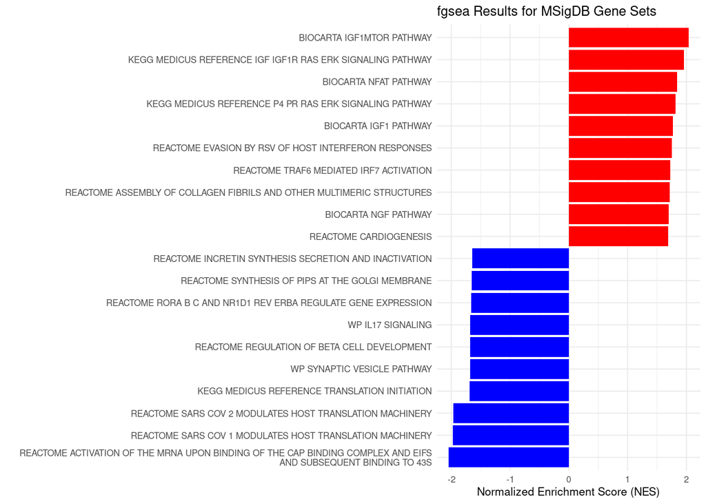

```r
top_pos <- fgsea_results %>% slice_max(NES, n = 10) %>% pull(pathway)
top_neg <- fgsea_results %>% slice_min(NES, n = 10) %>% pull(pathway)

subset <- fgsea_results %>% filter(pathway %in% c(top_pos, top_neg)) %>% mutate(pathway = factor(pathway)) %>% mutate(plot_name = str_replace_all(pathway, '_', ' '))

subset %>%
  mutate(plot_name = forcats::fct_reorder(factor(plot_name), NES)) %>%
  ggplot() +
  geom_bar(aes(x = plot_name, y = NES, fill = NES > 0), stat = 'identity', show.legend = FALSE) +
  scale_fill_manual(values = c('TRUE' = 'red', 'FALSE' = 'blue')) +
  theme_minimal(base_size = 8) +
  ggtitle('fgsea Results for MSigDB Gene Sets') +
  ylab('Normalized Enrichment Score (NES)') +
  xlab('') +
  scale_x_discrete(labels = function(x) str_wrap(x, width = 80)) +
  coord_flip()
```

**Differential Expression Analysis**